# Visualisation des résultats : tableaux et graphiques

(Idéalement, faire cela avant l’analyse…!)

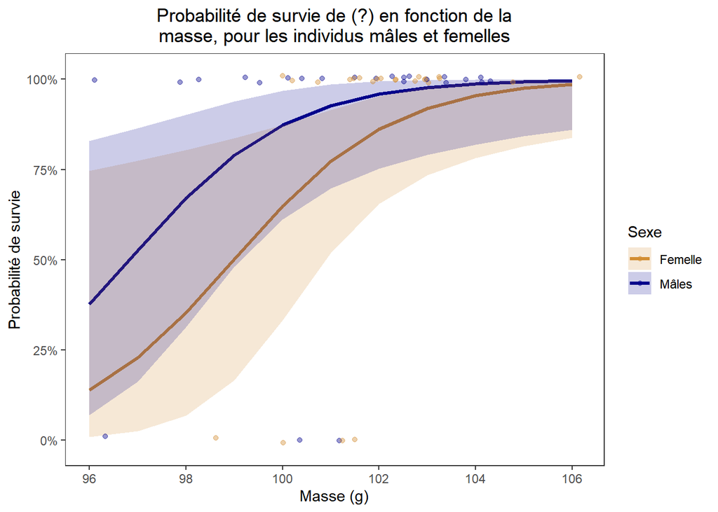

```r
plot.masse.sexe <- ggplot()+
geom_line(data = predictions.masse.sexe,
          aes(x = x, y = predicted, color = group),
          show.legend = TRUE,
          linewidth = 1.1)+
scale_color_manual(name = "Sexe",
                   labels = c("Femelle", "Mâles"),
                   values = c("0" = "#D28D32", "1" = "darkblue"))+
geom_ribbon(data = predictions.masse.sexe,
            show.legend = TRUE,
            aes(x = x, y = predicted, fill = group, ymin = conf.low, ymax = conf.high),
            alpha = 0.2)+
scale_fill_manual(name = "Sexe",
                  labels = c("Femelle", "Mâles"),
                  values = c("0" = "#D28D32", "1" = "darkblue"))+
geom_point(data = surv, aes(x = masse, y = survie, col = sex),
           alpha = .4,
           position = position_jitter(0.1, height = 0.01))+
labs(x = "Masse (g)",
     y = "Probabilité de survie",
     title = "Probabilité de survie de (?) en fonction de la\nmasse, pour les individus mâles et femelles")+
theme_bw()+
theme(panel.grid.major = element_blank(),
      panel.grid.minor = element_blank(),
      plot.title = element_text(hjust = 0.5))+
scale_y_continuous(labels = scales::percent,
                   limits = c(-0.02, 1.02))+
scale_x_continuous(breaks = seq(96, 106, by = 2))

plot.masse.sexe
```

Si on avait une troisième variable dans notre modèle, par exemple l’âge:

```r
head(surv)
```

```
##       masse      age sex survie
## 1 103.31373 60.43044   0      1
## 2 100.38447 63.11296   1      1
## 3 101.89734 60.85186   1      1
## 4  98.54894 62.10991   0      0
## 5 101.82275 59.57312   0      1
## 6 102.47745 56.40091   1      1
```

On peut l’ajouter à notre modèle:

```r
modele.masse.sexe.age <- with(surv, glm(survie ~ masse + sex + age, family = binomial))

summary(modele.masse.sexe.age)
```

```
##
## Call:
## glm(formula = survie ~ masse + sex + age, family = binomial)
##
## Coefficients:
##             Estimate Std. Error z value Pr(>|z|)
## (Intercept) -69.8689    30.8379  -2.266   0.0235 *
## masse         0.6183     0.2599   2.379   0.0173 *
## sex1          1.4678     1.1074   1.325   0.1850
## age           0.1434     0.2213   0.648   0.5171
## ---
## Signif. codes:  0 '***' 0.001 '**' 0.01 '*' 0.05 '.' 0.1 ' ' 1
##
## (Dispersion parameter for binomial family taken to be 1)
##
##     Null deviance: 39.880  on 47  degrees of freedom
## Residual deviance: 31.972  on 44  degrees of freedom
## AIC: 39.972
##
## Number of Fisher Scoring iterations: 6
```

Ok, cette variable n’est pas significative non plus. Mais encore une fois, essayons de la visualiser **pour l’exercice**.

On débute avec le calcul des prédictions, en ajoutant la variable `age`:

```r
predictions.masse.sexe.age <- ggpredict(modele.masse.sexe.age, c("masse","sex","age"))
```

```
## Data were 'prettified'. Consider using `terms="masse [all]"` to get
##   smooth plots.
```

```r
predictions.masse.sexe.age
```

```
## # Predicted probabilities of survie
##
## # sex = 0
## # age = 57.64
##
## masse | Predicted |       95% CI
## --------------------------------
##    96 |      0.10 | [0.00, 0.72]
##    99 |      0.40 | [0.08, 0.83]
##   101 |      0.70 | [0.33, 0.92]
##   106 |      0.98 | [0.76, 1.00]
##
## # sex = 1
## # age = 57.64
##
## masse | Predicted |       95% CI
## --------------------------------
##    96 |      0.32 | [0.05, 0.82]
##    99 |      0.75 | [0.38, 0.93]
##   101 |      0.91 | [0.63, 0.98]
##   106 |      1.00 | [0.84, 1.00]
##
## # sex = 0
## # age = 59.98
##
## masse | Predicted |       95% CI
## --------------------------------
##    96 |      0.13 | [0.01, 0.73]
##    99 |      0.49 | [0.16, 0.83]
##   101 |      0.77 | [0.51, 0.91]
##   106 |      0.99 | [0.83, 1.00]
##
## # sex = 1
## # age = 59.98
##
## masse | Predicted |       95% CI
## --------------------------------
##    96 |      0.39 | [0.07, 0.84]
##    99 |      0.80 | [0.49, 0.95]
##   101 |      0.93 | [0.71, 0.99]
##   106 |      1.00 | [0.87, 1.00]
##
## # sex = 0
## # age = 62.32
##
## masse | Predicted |       95% CI
## --------------------------------
##    96 |      0.17 | [0.01, 0.80]
##    99 |      0.57 | [0.18, 0.89]
##   101 |      0.82 | [0.51, 0.95]
##   106 |      0.99 | [0.84, 1.00]
##
## # sex = 1
## # age = 62.32
##
## masse | Predicted |       95% CI
## --------------------------------
##    96 |      0.47 | [0.07, 0.91]
##    99 |      0.85 | [0.45, 0.98]
##   101 |      0.95 | [0.68, 0.99]
##   106 |      1.00 | [0.87, 1.00]
```

```
##
## Not all rows are shown in the ouput. Use `print(..., n = Inf)` to show
##   all rows.
```

Nous obtenons 6 tables de prédictions. Puisque `age` est une variable continue, `ggpredict` nous a choisi 3 valeurs de `age` représentatives de la distribution et a calculé un `y` prédit pour chacunes de ces valeurs et pour les 2 niveaux de `sex`.

Ici nous avons deux options. Puisque nous avons une troisième variable indépendante à représenter, on peut lui assigner un `aes()`, par exemple `linetype`.

Nous avons donc, dans nos tables de prédiction:

`masse` = `x` = `x`

`survie` = `y` = `predicted`

`sex` = `color` = `group`

Dans la table de prédiction, bien que ce ne soit pas affiché, la troisième variable indépendante est appelée `facet`, comme on peut remarquer dans

```r
str(predictions.masse.sexe.age)
```

```
## Classes 'ggeffects' and 'data.frame':    66 obs. of  7 variables:
##  $ x        : int  96 96 96 96 96 96 97 97 97 97 ...
##  $ predicted: num  0.0958 0.1291 0.1717 0.315 0.3914 ...
##  $ std.error: num  1.63 1.48 1.51 1.16 1.08 ...
##  $ conf.low : num  0.00433 0.00803 0.01063 0.04535 0.07209 ...
##  $ conf.high: num  0.721 0.731 0.8 0.817 0.842 ...
##  $ group    : Factor w/ 2 levels "0","1": 1 1 1 2 2 2 1 1 1 2 ...
##  $ facet    : Factor w/ 3 levels "57.64","59.98",..: 1 2 3 1 2 3 1 2 3 1 ...
##  - attr(*, "numeric.facet")= logi TRUE
##  - attr(*, "legend.labels")= chr [1:2] "0" "1"
##  - attr(*, "x.is.factor")= chr "0"
##  - attr(*, "continuous.group")= logi FALSE
##  - attr(*, "rawdata")='data.frame':  48 obs. of  5 variables:
##   ..$ response: int [1:48] 1 1 1 0 1 1 1 1 1 1 ...
##   ..$ x       : num [1:48] 103.3 100.4 101.9 98.5 101.8 ...
##   ..$ group   : Factor w/ 2 levels "0","1": 1 2 2 1 1 2 1 2 1 2 ...
##   ..$ facet   : num [1:48] 60.4 63.1 60.9 62.1 59.6 ...
##   ..$ rowname : chr [1:48] "1" "2" "3" "4" ...
##  - attr(*, "title")= chr "Predicted probabilities of survie"
##  - attr(*, "x.title")= chr "masse"
##  - attr(*, "y.title")= chr "survie"
##  - attr(*, "legend.title")= chr "sex"
##  - attr(*, "constant.values")= Named list()
##  - attr(*, "terms")= chr [1:3] "masse" "sex" "age"
##  - attr(*, "original.terms")= chr [1:3] "masse" "sex" "age"
##  - attr(*, "at.list")=List of 3
##   ..$ masse: int [1:11] 96 97 98 99 100 101 102 103 104 105 ...
##   ..$ sex  : chr [1:2] "0" "1"
##   ..$ age  : num [1:3] 57.6 60 62.3
##  - attr(*, "ci.lvl")= num 0.95
##  - attr(*, "type")= chr "fe"
##  - attr(*, "response.name")= chr "survie"
##  - attr(*, "back.transform")= logi TRUE
##  - attr(*, "response.transform")= chr "survie"
##  - attr(*, "untransformed.predictions")= num [1:66] 0.0958 0.1291 0.1717 0.315 0.3914 ...
##  - attr(*, "family")= chr "binomial"
##  - attr(*, "link")= chr "logit"
##  - attr(*, "logistic")= chr "1"
##  - attr(*, "link_inverse")=function (eta)
##  - attr(*, "link_function")=function (mu)
##  - attr(*, "is.trial")= chr "0"
##  - attr(*, "fitfun")= chr "glm"
##  - attr(*, "verbose")= logi TRUE
##  - attr(*, "model.name")= chr "modele.masse.sexe.age"
```

Dans ce cas, on ajoute l’`aes()` `linetype` à `geom_line` assigné à `facet`:

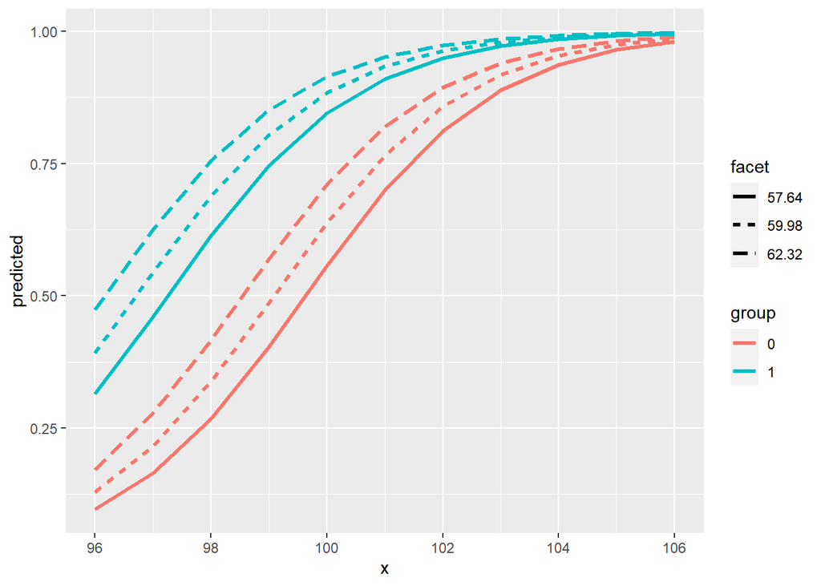

```r
plot.masse.sexe.age1 <- ggplot()+
geom_line(data = predictions.masse.sexe.age,
          aes(x = x, y = predicted, color = group, linetype = facet),
          show.legend = TRUE,
          linewidth=1.1)

plot.masse.sexe.age1
```

On peut voir dans la légende les 3 valeurs de `age` qui ont été utilisées pour le calcul.

La deuxième option serait d’utiliser des facettes. Ceci crée des graphiques côte à côte avec différents niveaux d’une variable choisie. Dans ce cas, j’enlève l’`aes()` qu’on vient d’ajouter, et j’ajoute la fonction `facet_wrap(~facet)`, qui crée 3 facettes avec notre “variable” `facet`:

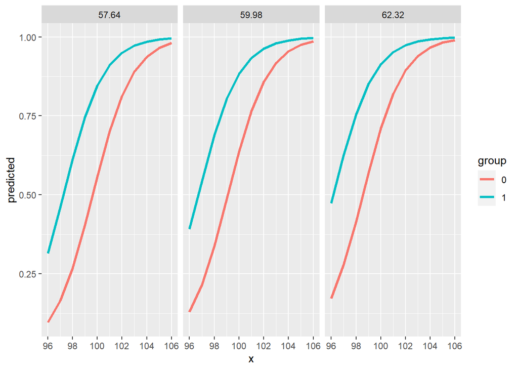

```r
plot.masse.sexe.age2 <- ggplot()+
geom_line(data = predictions.masse.sexe.age,
          aes(x = x, y = predicted, color = group),
          show.legend = TRUE,
          linewidth = 1.1)+
facet_wrap(~ facet)

plot.masse.sexe.age2
```

On peut terminer ce graphique, avec le même code que les précédents. J’ajoute `labeller` dans `facet_wrap` pour changer le titre des étiquettes. J’ai arrondi l’âge pour les étiquettes.

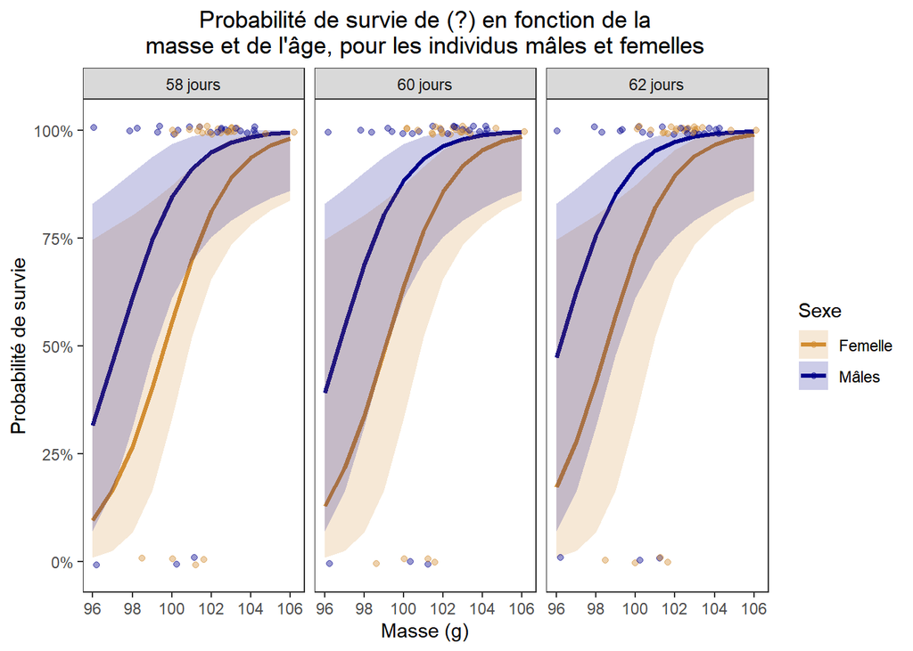

```r
plot.masse.sexe.age2 <- ggplot()+
geom_line(data = predictions.masse.sexe.age,
          aes(x = x, y = predicted, color = group),
          show.legend = TRUE,
          linewidth = 1.1)+
scale_color_manual(name = "Sexe",
                   labels = c("Femelle", "Mâles"),
                   values = c("0" = "#D28D32", "1" = "darkblue"))+
geom_ribbon(data = predictions.masse.sexe,
            show.legend = TRUE,
            aes(x = x, y = predicted, fill = group, ymin = conf.low, ymax = conf.high),
            alpha = 0.2)+
scale_fill_manual(name = "Sexe",
                  labels = c("Femelle", "Mâles"),
                  values = c("0" = "#D28D32", "1" = "darkblue"))+
geom_point(data = surv,
           aes(x = masse, y = survie, col = sex),
           alpha = .4,
           position = position_jitter(0.1, height = 0.01))+
labs(x = "Masse (g)",
     y = "Probabilité de survie",
     title = "Probabilité de survie de (?) en fonction de la\nmasse et de l'âge, pour les individus mâles et femelles")+
theme_bw()+
theme(panel.grid.major = element_blank(),
      panel.grid.minor = element_blank(),
      plot.title = element_text(hjust = 0.5))+
scale_y_continuous(labels = scales::percent,
                   limits = c(-0.02, 1.02))+
scale_x_continuous(breaks = seq(96, 106, by = 2))+
facet_wrap(~ facet, labeller = labeller(facet = c( "57.64" = "58 jours", "59.98" = "60 jours",  "62.32" = "62 jours")))

plot.masse.sexe.age2
```

Vous pouvez vous pratiquer en complétant la première option!

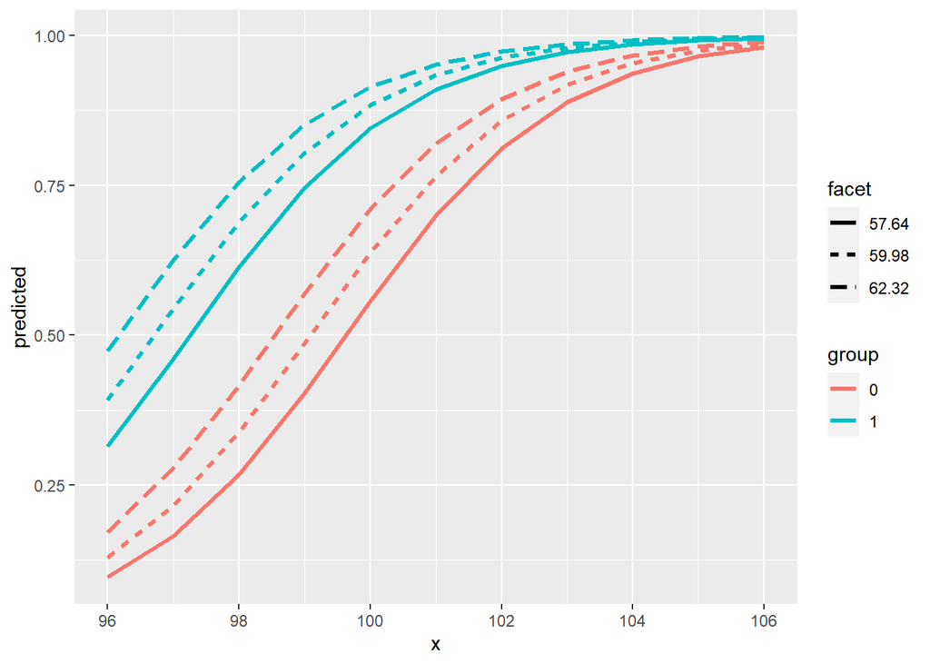

```r
plot.masse.sexe.age1
```

# Régression linéaire simple

Maintenant qu’on a fait un exemple plus compliqué, essayons d’illustrer un modèle linéaire simple.

Reprenons les données `iris()`

```r
head(iris)
```

```
##   Sepal.Length Sepal.Width Petal.Length Petal.Width Species
## 1          5.1         3.5          1.4         0.2  setosa
## 2          4.9         3.0          1.4         0.2  setosa
## 3          4.7         3.2          1.3         0.2  setosa
## 4          4.6         3.1          1.5         0.2  setosa
## 5          5.0         3.6          1.4         0.2  setosa
## 6          5.4         3.9          1.7         0.4  setosa
```

On peut créer un modèle linéaire pour prédire `Sepal.Length` en fonction de `Petal.Length`:

**Encore une fois, ce n’est qu’un exemple pour s’exercer avec `ggplot()`. Il ne faut pas oublier les étapes préliminaires, que je saute ici, avant de se lancer dans un modèle.**

```r
regr.SL <- lm(Sepal.Length ~ Petal.Length, data = iris)
summary(regr.SL)
```

```
##
## Call:
## lm(formula = Sepal.Length ~ Petal.Length, data = iris)
##
## Residuals:
##      Min       1Q   Median       3Q      Max
## -1.24675 -0.29657 -0.01515  0.27676  1.00269
##
## Coefficients:
##              Estimate Std. Error t value Pr(>|t|)
## (Intercept)   4.30660    0.07839   54.94   <2e-16 ***
## Petal.Length  0.40892    0.01889   21.65   <2e-16 ***
## ---
## Signif. codes:  0 '***' 0.001 '**' 0.01 '*' 0.05 '.' 0.1 ' ' 1
##
## Residual standard error: 0.4071 on 148 degrees of freedom
## Multiple R-squared:   0.76,  Adjusted R-squared:  0.7583
## F-statistic: 468.6 on 1 and 148 DF,  p-value: < 2.2e-16
```

Enfin quelque chose de significatif! Super, nous pouvons représenter cettre relation.

Avec une régression linéaire simple, évidemment, nous n’avons pas besoin d’une fonction comme `ggpredict` pour calculer y.

On peut commencer par spécifier les `aes()` **du jeu de données brutes** directement dans `ggplot()`; ensuite, nous visualisons ces données avec `geom_point`; puis, `geom_smooth(method = lm)` (calcule, puis) ajoute la courbe de la régression.

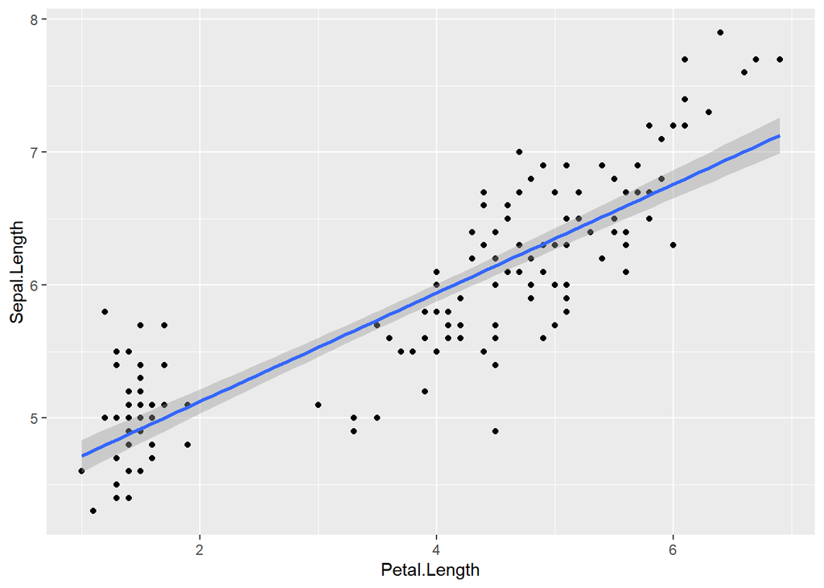

```r
plot.regr.SL <- ggplot(data = iris, aes(x = Petal.Length, y = Sepal.Length))+
geom_point()+
geom_smooth(method = lm,
            se = TRUE)

plot.regr.SL
```

On peut embellir notre graphique:

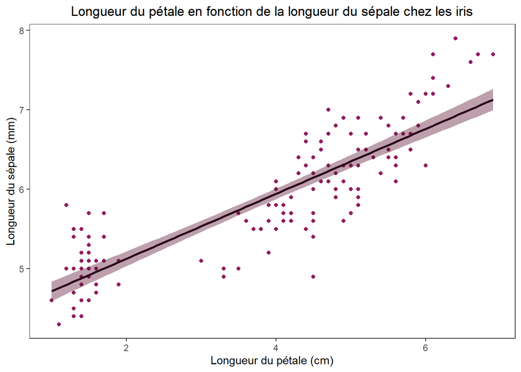

```r
plot.regr.SL <- ggplot(data = iris, aes(x = Petal.Length, y = Sepal.Length))+
geom_point(col = "#8F1E5F")+
geom_smooth(method = lm,
            se = TRUE,
            col = "#2B091D",
            fill = "#591130")+
labs(x = "Longueur du pétale (cm)",
     y = "Longueur du sépale (mm)",
     title = "Longueur du pétale en fonction de la longueur du sépale chez les iris")+
theme_bw()+
theme(panel.grid.major = element_blank(),
      panel.grid.minor = element_blank(),
      plot.title = element_text(hjust = 0.5))

plot.regr.SL
```

On retourne voir le résumé de notre modèle pour ajouter la statistique:

```r
summary(regr.SL)
```

```
##
## Call:
## lm(formula = Sepal.Length ~ Petal.Length, data = iris)
##
## Residuals:
##      Min       1Q   Median       3Q      Max
## -1.24675 -0.29657 -0.01515  0.27676  1.00269
##
## Coefficients:
##              Estimate Std. Error t value Pr(>|t|)
## (Intercept)   4.30660    0.07839   54.94   <2e-16 ***
## Petal.Length  0.40892    0.01889   21.65   <2e-16 ***
## ---
## Signif. codes:  0 '***' 0.001 '**' 0.01 '*' 0.05 '.' 0.1 ' ' 1
##
## Residual standard error: 0.4071 on 148 degrees of freedom
## Multiple R-squared:   0.76,  Adjusted R-squared:  0.7583
## F-statistic: 468.6 on 1 and 148 DF,  p-value: < 2.2e-16
```

Et on l’ajoute au graphique:

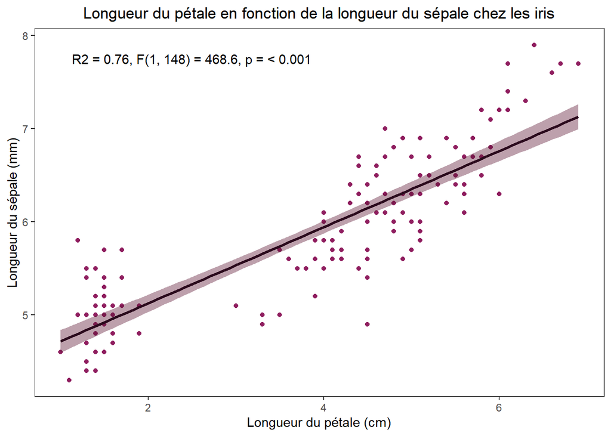

```r
plot.regr.SL <- ggplot(data = iris, aes(x = Petal.Length, y = Sepal.Length))+
geom_point(col="#8F1E5F")+
geom_smooth(method = lm,
            se = TRUE, col = "#2B091D", fill = "#591130")+
labs(x = "Longueur du pétale (cm)",
     y = "Longueur du sépale (mm)",
     title = "Longueur du pétale en fonction de la longueur du sépale chez les iris")+
theme_bw()+
theme(panel.grid.major = element_blank(),
      panel.grid.minor = element_blank(),
      plot.title = element_text(hjust = 0.5))+
annotate("text",
         x = 2.5, y = 7.75,
         label = "R2 = 0.76, F(1, 148) = 468.6, p = < 0.001")

plot.regr.SL
```

C’est important d’ajouter un intervalle de confiance, ainsi qu’un intervalle de prédiction. L’intervalle de confiance s’affiche avec `geom_smooth(se = TRUE)`. Pour ce qui est de l’intervalle de prédiction, la fonction `predict()` calcule ces valeurs, puis colle ce nouveau dataframe à `iris` pour créer `iris.int.pred`. Nous utiliserons maintenant cette nouvelle table pour notre régression.

```r
int.pred <- predict(regr.SL, interval = "prediction")
iris.int.pred <- cbind(iris, int.pred)
head(iris.int.pred)
```

```
##   Sepal.Length Sepal.Width Petal.Length Petal.Width Species      fit      lwr
## 1          5.1         3.5          1.4         0.2  setosa 4.879095 4.067202
## 2          4.9         3.0          1.4         0.2  setosa 4.879095 4.067202
## 3          4.7         3.2          1.3         0.2  setosa 4.838202 4.025897
## 4          4.6         3.1          1.5         0.2  setosa 4.919987 4.108491
## 5          5.0         3.6          1.4         0.2  setosa 4.879095 4.067202
## 6          5.4         3.9          1.7         0.4  setosa 5.001771 4.191017
##        upr
## 1 5.690987
## 2 5.690987
## 3 5.650508
## 4 5.731483
## 5 5.690987
## 6 5.812526
```

Dans `geom_ribbon(aes(ymin = lwr, ymax = upr)`, les `aes()` permettent d’assigner les bornes supérieures et inférieures (en y) du ruban aux variables `lwr` et `upr` que nous venons de calculer et ajouter à notre table.

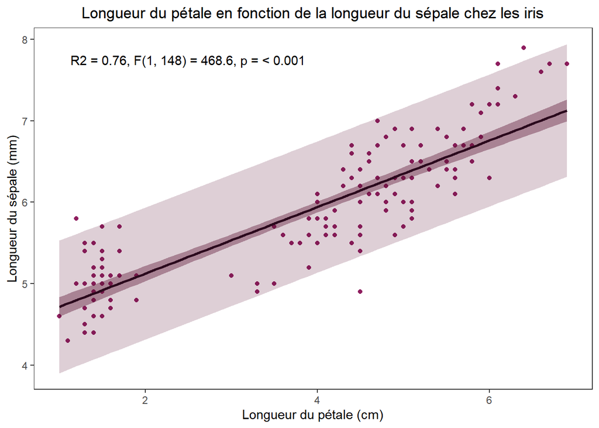

```r
plot.regr.SL <- ggplot(data = iris.int.pred, aes(x = Petal.Length, y = Sepal.Length))+
geom_point(col = "#8F1E5F")+
geom_ribbon(aes(ymin = lwr, ymax = upr),
            alpha = .2,
            fill = "#591130")+
geom_smooth(method = lm,
            se = TRUE,
            col = "#2B091D",
            fill = "#591130")+
labs(x = "Longueur du pétale (cm)",
     y = "Longueur du sépale (mm)",
     title = "Longueur du pétale en fonction de la longueur du sépale chez les iris")+
theme_bw()+
theme(panel.grid.major = element_blank(),
      panel.grid.minor = element_blank(),
      plot.title = element_text(hjust = 0.5))+
annotate("text",
         x = 2.5, y = 7.75,
         label = "R2 = 0.76, F(1, 148) = 468.6, p = < 0.001")

plot.regr.SL
```

Wow!

# *Cheat sheet* `ggplot()`

Maintenant que vous êtes plus familiers avec `ggplot()`, voici un lien pour une *cheat sheet* pour `ggplot()`:

https://rstudio.github.io/cheatsheets/html/data-visualization.html

Elle contient toute l’information sur les différents `aes()`, `geom_*()`, `scale_*`, ainsi que sur les thèmes, les ajustements de position, et les légendes, par exemple.

# À considérer lors de la création de figures

Comme mentionné plus tôt, il faut être judicieux dans le choix de notre symbologie. En effet, les couleurs et les symboles ont souvent un sens qui nous est intuitif, et représentent ainsi de l’information - quelles couleurs choisiriez-vous pour illustrer une température chaude? Froide?

Ces choix de couleur contribuent à donner un sens à vos figures. Il existe des palettes de couleurs conçue pour illustrer des données, par exemple, d’élévation, ou de température. Certaines sont conçues pour maximiser le contraste entre les extrêmes des valeurs d’une variable.

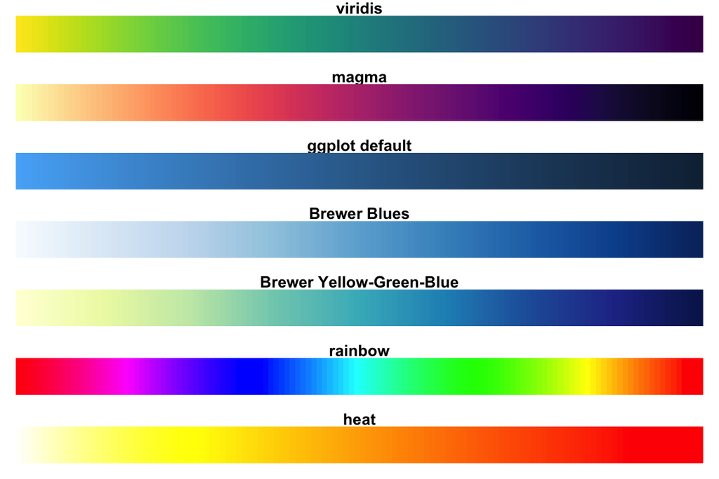

Il existe même une palette, “Okabe-Ito”, contenant des couleurs qui sont plus accessibles pour les gens ayant une variété de problèmes visuels. D’autres palettes sont simplement esthétiques.

On doit aussi penser au type de variable que nous souhaitons illustrer. Par exemple, il serait moins approprié d’utiliser la valeur (donc de pâle à foncé) d’une même couleur pour colorer des variables catégoriques qui ne sont pas ordonnées (pensez aux boxplots des espèces d’iris), puisque celle-ci traduit la notion d’ordre et de progression. Une palette avec des couleurs aléatoires comme celle que nous avons utilisée est mieux dans ce cas. La valeur serait toutefois appropriée pour des données de concentration, par exemple.

Toutefois, certaines publications scientifiques n’acceptent que les figures en noir et blanc; dans ce cas, on peut utiliser des symboles, des textures (par exemple, le grain peut être utilisé au lieu de la valeur), ou différentes lignes pointillées, par exemple.

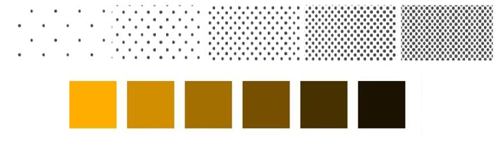

De plus, assurez-vous que vos axes sont représentatifs de vos données.

Pour terminer, utilisez une fonction pour exporter vos figures. “Copier-coller” ne suffit pas, car la résolution ne sera pas assez bonne.

Voici un exemple:

`ggsave(path = "votre_chemin_comme_dans_setwd()", "titre_de_votre_figures.jpeg", width = 6, height = 6, dpi=700)`

# Ordinations

Comme pour les analyses univariées, cet atelier est seulement axé sur la création de graphiques. Pour une introduction aux analyses multivariées (ordinations, PERMANOVA, Procrustes), consulter l’atelier 6.

## Importer les données multivariées

```r
library(vegan)
data(dune) # matrice de communautés
data(dune.env) # données environnementales
```

Ce jeu de données contient une matrice d’abondance (dune) d’espèces végétales avec leur classe de couverture pour 20 sites. Le dataframe (dune.env) contient 5 variables denvironnementales.

# PCA

## Préparation des données

Transformation Hellinger

```r
dune.hel <- decostand(dune, method="hellinger")
```

Faire une PCA (avec la fonction `prcomp` cette fois-ci, car l’objet qu’on va créer peut être “lu” plus tard par la fonction `ggord`)

```r
pca.dune <- prcomp(dune.hel)
summary(pca.dune)
```

```
## Importance of components:
##                           PC1    PC2    PC3    PC4     PC5     PC6     PC7
## Standard deviation     0.4122 0.3333 0.2374 0.2097 0.20242 0.17376 0.14506
## Proportion of Variance 0.3057 0.1998 0.1013 0.0791 0.07371 0.05431 0.03785
## Cumulative Proportion  0.3057 0.5054 0.6068 0.6859 0.75960 0.81391 0.85177
##                            PC8     PC9    PC10    PC11    PC12    PC13    PC14
## Standard deviation     0.13392 0.11745 0.10441 0.09995 0.09550 0.07985 0.07188
## Proportion of Variance 0.03226 0.02481 0.01961 0.01797 0.01641 0.01147 0.00929
## Cumulative Proportion  0.88403 0.90885 0.92846 0.94643 0.96283 0.97430 0.98360
##                           PC15    PC16    PC17    PC18    PC19      PC20
## Standard deviation     0.05424 0.05240 0.04063 0.03373 0.02536 4.415e-17
## Proportion of Variance 0.00529 0.00494 0.00297 0.00205 0.00116 0.000e+00
## Cumulative Proportion  0.98889 0.99383 0.99680 0.99884 1.00000 1.000e+00
```

Dans l’atelier 6, nous avons fait nos PCA avec la fonction `rda`. Lorsqu’on compare le sommaire des deux analyses, on voit que les deux fonctions donnent les mêmes résultats.

```r
pca2.dune <- rda(dune.hel)
summary(pca2.dune)
```

```
##
## Call:
## rda(X = dune.hel)
##
## Partitioning of variance:
##               Inertia Proportion
## Total          0.5559          1
## Unconstrained  0.5559          1
##
## Eigenvalues, and their contribution to the variance
##
## Importance of components:
##                          PC1    PC2     PC3     PC4     PC5     PC6     PC7
## Eigenvalue            0.1699 0.1111 0.05634 0.04397 0.04097 0.03019 0.02104
## Proportion Explained  0.3057 0.1998 0.10135 0.07910 0.07371 0.05431 0.03785
## Cumulative Proportion 0.3057 0.5054 0.60679 0.68590 0.75960 0.81391 0.85177
##                           PC8     PC9    PC10     PC11    PC12     PC13
## Eigenvalue            0.01794 0.01379 0.01090 0.009991 0.00912 0.006376
## Proportion Explained  0.03226 0.02481 0.01961 0.017972 0.01641 0.011469
## Cumulative Proportion 0.88403 0.90885 0.92846 0.946428 0.96283 0.974303
##                           PC14     PC15     PC16     PC17     PC18      PC19
## Eigenvalue            0.005166 0.002942 0.002745 0.001651 0.001138 0.0006432
## Proportion Explained  0.009293 0.005292 0.004939 0.002969 0.002047 0.0011570
## Cumulative Proportion 0.983597 0.988888 0.993827 0.996796 0.998843 1.0000000
##
## Scaling 2 for species and site scores
## * Species are scaled proportional to eigenvalues
## * Sites are unscaled: weighted dispersion equal on all dimensions
## * General scaling constant of scores:  1.80276
##
##
## Species scores
##
##                 PC1       PC2       PC3       PC4        PC5        PC6
## Achimill  0.2241355 -0.057048  0.068674  0.173281 -0.0498964  0.0006022
## Agrostol -0.4142446  0.180068 -0.020078  0.020756  0.0029054 -0.0193453
## Airaprae  0.0350694 -0.154644 -0.116317  0.039999 -0.1384374  0.0376930
## Alopgeni -0.1386550  0.318444 -0.186419 -0.001329  0.0030171  0.0215368
## Anthodor  0.1962910 -0.238579 -0.095768  0.179434 -0.0380470  0.0471885
## Bellpere  0.1148332  0.054380  0.057640 -0.064957  0.0010453 -0.0896219
```

[output cut: 34 more lines]

```
## 6   0.389342 -0.20337  1.022e-01  0.30549  0.758789  0.245696
## 7   0.451813 -0.06864  6.835e-02  0.41821  0.585536  0.138732
## 8  -0.295113  0.29375  6.362e-02 -0.19828  0.010903  0.185034
## 9  -0.035973  0.49264 -2.714e-01 -0.07945  0.086166  0.419257
## 10  0.453094 -0.13639  2.391e-01  0.12201  0.144355 -0.462946
## 11  0.273214 -0.29633 -3.931e-05 -0.87663  0.126762 -0.097096
## 12 -0.246622  0.33173 -9.205e-01  0.03527  0.493526  0.017653
## 13 -0.226908  0.48390 -6.740e-01  0.28663 -0.071279 -0.323642
## 14 -0.570818 -0.25288  3.165e-01  0.32869 -0.085439 -1.196310
## 15 -0.654415 -0.28845  3.733e-01 -0.01035  0.196968 -0.002255
## 16 -0.720030  0.10689  2.727e-01  0.35992  0.007984  0.504518
## 17  0.317465 -0.75272 -3.395e-01  0.64284 -0.803236  0.262492
## 18  0.201131 -0.39818  2.007e-01 -0.89875  0.365682 -0.086314
## 19 -0.006263 -0.73205 -8.167e-01 -0.33669 -0.503443  0.085674
## 20 -0.689579 -0.36848  4.077e-01 -0.09888 -0.048247  0.475587
```

```r
dune.dist <- vegdist(decostand(dune, method='hellinger'), method='euclid')
disper.dune <- betadisper(dune.dist, dune.env$Management)
anova(disper.dune)
```

```
## Analysis of Variance Table
##
## Response: Distances
##           Df  Sum Sq  Mean Sq F value Pr(>F)
## Groups     3 0.17812 0.059373  1.5729 0.2349
## Residuals 16 0.60397 0.037748
```

```r
permanova.dune <- adonis2(dune.dist ~ Management, data = dune.env)
permanova.dune
```

```
## Permutation test for adonis under reduced model
## Terms added sequentially (first to last)
## Permutation: free
## Number of permutations: 999
##
## adonis2(formula = dune.dist ~ Management, data = dune.env)
##            Df SumOfSqs      R2      F Pr(>F)
## Management  3   3.1672 0.29986 2.2842  0.006 **
## Residual   16   7.3950 0.70014
## Total      19  10.5621 1.00000
## ---
## Signif. codes:  0 '***' 0.001 '**' 0.01 '*' 0.05 '.' 0.1 ' ' 1
```

Le test montre que le type d’aménagement a un effet statistiquement significatif sur la composition en espèces végétales des sites.

## ggord + ggplot

On va créer un graphique pour présenter la PCA avec les différents types d’aménagement.

Extraire les scores des sites et des espèces, à partir de l’objet créer par `prcomp`. Cela va nous permettre de mettre éventuellement seulement les espèces désirées sur le graphique.

```r
site.scores<-pca.dune$x
site.scores.df <- data.frame(site.scores)
sp.scores<-pca.dune$rotation
sp.scores.df <- data.frame(sp.scores)
```

Ouverture des librairies nécessaires à la création du graphique. Si problème avec installation de la librairie ggord : https://rdrr.io/github/fawda123/ggord/

```r
library(ggord)
```

```r
library(ggplot2)
library(ggrepel) # pour éviter overlap du texte
```

On va d’abord commencer le graphique avec la fonctions `ggord` du package du même nom.

Le graphique créé par la fonction `ggord` est un objet ggplot. Cet objet (ici appelé pca.plot) peut être personnalisé à même la fonction `ggord`, et peut aussi servir de base sur laquelle ajouter des couches avec ggplot.

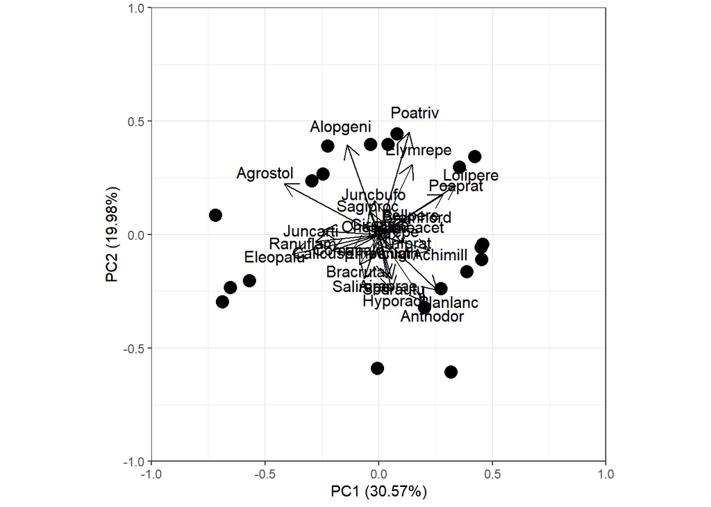

```r
pca.plot <- ggord(pca.dune, xlims=c(-1,1), ylims=c(-1,1)) # xlims et ylims définissent les limites dans l'affichage des axe (les valeurs entre parenthèses correspondent à l'échelle numérique des axes). On ajuste au fur et à mesure, au besoin.
pca.plot # À la fin de chaque chunk, l'objet graphique est appelé pour qu'on visualise le rendu à chaque fois.
```

On remarque que la fonction`ggord` inclut par défaut la **proportion de la variance expliquée par les axes**. C’est super!

Par défaut, la fonction `ggord` va mettre en graphique les deux premiers axes de l’ordination. Mais si on s’intéresse à différents axes, on peut spécifier lesquels mettre en graphique.

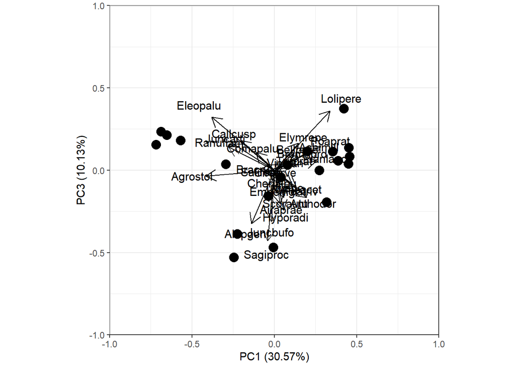

```r
pca.plot <- ggord(pca.dune, xlims=c(-1,1), ylims=c(-1,1),
                  axes=c(1,3)) # Ici, on met en graphique les axes 1 et 3.
pca.plot
```

On revient aux deux premiers axes. Faisons quelques petits changements. Les changements sont marqués d’un “#” à côté de la ligne.

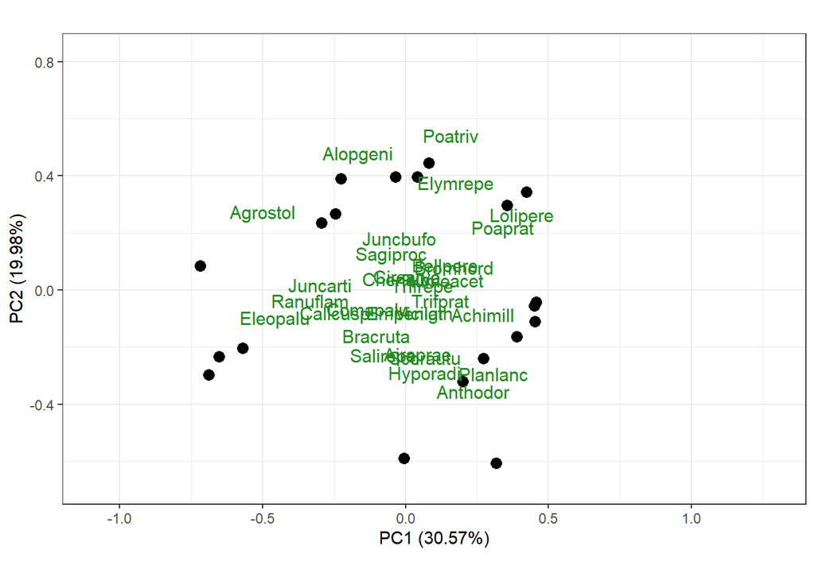

```r
pca.plot <- ggord(pca.dune, xlims=c(-1.2,1.4), ylims=c(-0.75,0.9), # ajustement des limites
                  axes=c(1,2), # retour aux axes 1 et 2
                  size=3, # diminution de la taille des points (sites)
                  arrow=NULL,# enlever les flèches (qui viennent par défaut) pour les espèces
                  labcol="forestgreen") # changer la couleur du texte pour les espèces
pca.plot
```

Faisons d’autres changements!

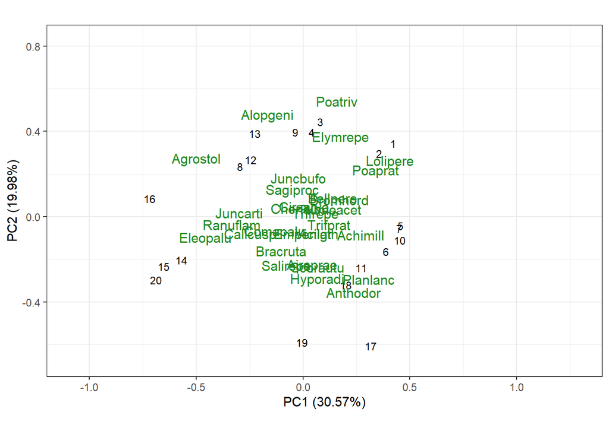

```r
pca.plot <- ggord(pca.dune, xlims=c(-1.2,1.4), ylims=c(-0.75,0.9),
                  axes=c(1,2),
                  size=3,
                  obslab=TRUE, # pour passer de points pour les sites (par défaut) à texte (nom des sites)
                  arrow=NULL,
                  labcol="forestgreen") # changer la couleur du texte pour les espèces
pca.plot
```

Il y a beaucoup d’espèces affichées au milieu et c’est illisible. En plus, les espèces au milieu ne contribuent pas beaucoup à la distinction compositionnelle des sites. On va donc garder seulement les quelques espèces dont les scores ont la valeur absolue la plus élevée, pour chacun des deux axes, qu’on met en graphique (ici PC1 et PC2).

D’abord, on va créer un nouveau dataframe contenant seulement ces espèces, en utilisant quelques fonctions de la librairie **dplyr**.

```r
A <- top_n(sp.scores.df, 3, PC1) # sélectionne les 3 espèces dont le score est le plus élevé sur l'axe 1.
B <- top_n(sp.scores.df, -3, PC1) # sélectionne les 3 espèces dont le score est le plus bas sur l'axe 1.
C <- top_n(sp.scores.df, 3, PC2) # sélectionne les 3 espèces dont le score est le plus élevé sur l'axe 2.
D <- top_n(sp.scores.df, -3, PC2) # sélectionne les 3 espèces dont le score est le plus bas sur l'axe 2.
sp.scores.skim <- bind_rows(A,B,C,D) # merge les sub dataframe A, B, C et D.
sp.scores.skim <- distinct(sp.scores.skim) # on ne garde que les rangées (espèces) qui sont uniques (pour éviter qu'une même espèce s'y retrouve en copies)
```

Mise en graphique de ces espèces seulement

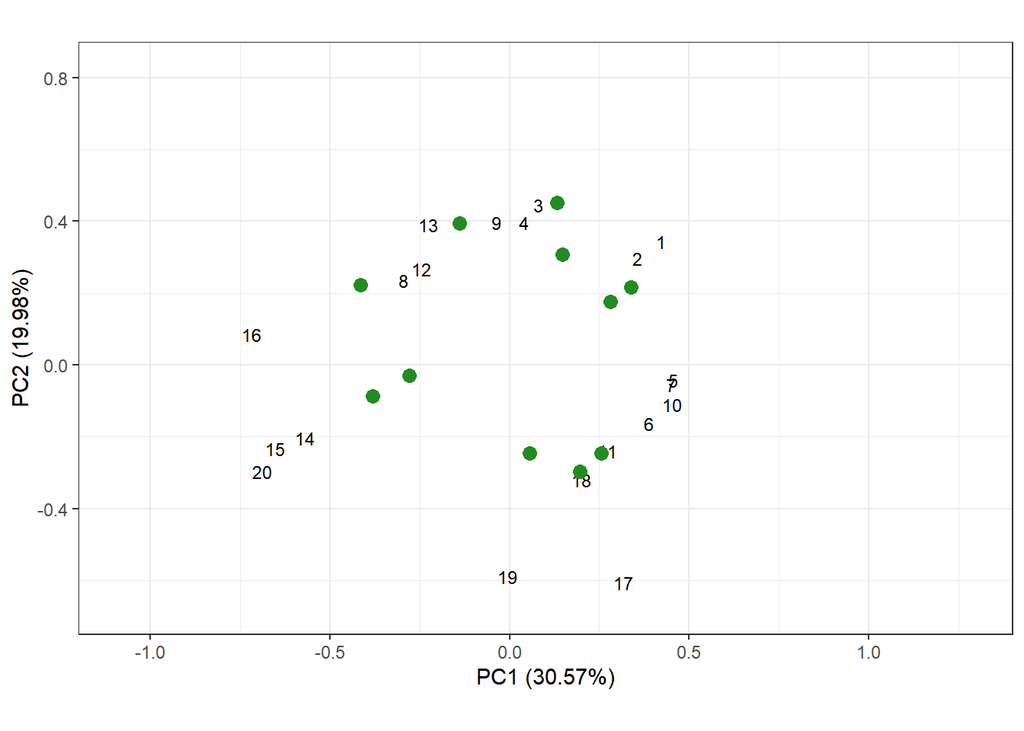

```r
pca.plot <- ggord(pca.dune, xlims=c(-1.2,1.4), ylims=c(-0.75,0.9),
                  axes=c(1,2),
                  size=3,
                  obslab=TRUE,
                  arrow=NULL,
                  txt=NULL, # enlever le texte (par défaut) pour les espèces
                  addpts=sp.scores.skim, # Ajouter les espèces aux plus hauts et faibles scores
                  addsize=3, # taille des points des espèces
                  addcol="forestgreen") # couleur des espèces
                  # on enlève l'argument labcol
pca.plot
```

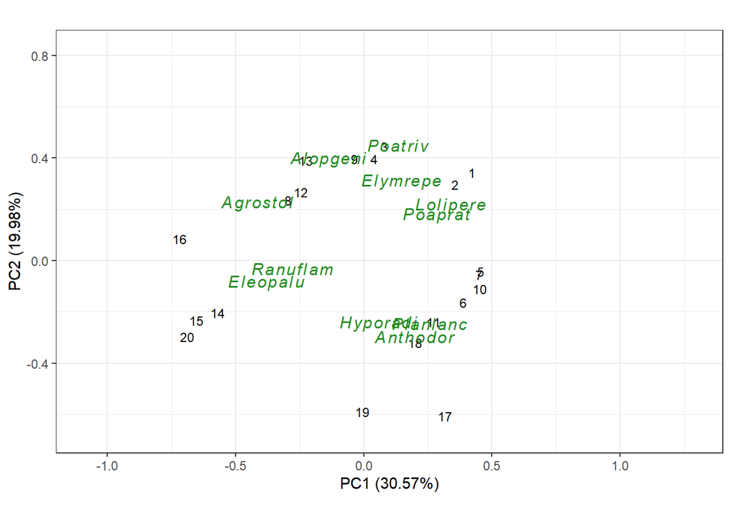

```r
pca.plot <- ggord(pca.dune, xlims=c(-1.2,1.4), ylims=c(-0.75,0.9),
                  axes=c(1,2),
                  size=3,
                  obslab=TRUE,
                  arrow=NULL,
                  txt=NULL,
                  addpts=sp.scores.skim,
                  addsize=4, # augmenter la taille du texte des espèces
                  ptslab=TRUE, # changer de points à texte pour les espèces
                  addcol="forestgreen")
pca.plot
```

On va ajouter les résultats d’un `envfit`. D’abord, on fait le test.

```r
(pca.envfit <- envfit(pca.dune, dune.env))
```

```
##
## ***VECTORS
##
##         PC1      PC2     r2 Pr(>r)
## A1 -0.97222 -0.23409 0.3622   0.01 **
## ---
## Signif. codes:  0 '***' 0.001 '**' 0.01 '*' 0.05 '.' 0.1 ' ' 1
## Permutation: free
## Number of permutations: 999
##
## ***FACTORS:
##
## Centroids:
##                  PC1     PC2
## Moisture1     0.3635 -0.0257
## Moisture2     0.2224  0.0314
## Moisture4    -0.1408  0.3321
## Moisture5    -0.4504 -0.0872
## ManagementBF  0.3597 -0.0173
## ManagementHF  0.1930  0.0745
## ManagementNM -0.2330 -0.3751
## ManagementSF -0.1077  0.3217
## UseHayfield   0.0994 -0.2242
## UseHaypastu   0.0203  0.2180
## UsePasture   -0.1716 -0.0350
## Manure0      -0.2330 -0.3751
## Manure1       0.2294  0.0161
## Manure2       0.2385  0.0895
## Manure3      -0.1969  0.1644
## Manure4       0.1812  0.3955
##
## Goodness of fit:
##                r2 Pr(>r)
## Moisture   0.5366  0.001 ***
## Management 0.4614  0.002 **
## Use        0.1794  0.131
## Manure     0.4531  0.017 *
## ---
## Signif. codes:  0 '***' 0.001 '**' 0.01 '*' 0.05 '.' 0.1 ' ' 1
## Permutation: free
## Number of permutations: 999
```

Pour incorporer les vecteurs résultant de ce test, il faut d’abord les extraire et les mettre dans un dataframe.

```r
vect <- data.frame(pca.envfit[["vectors"]][["arrows"]])
vect$variable.env<-rownames(vect)
```

[output not shown]

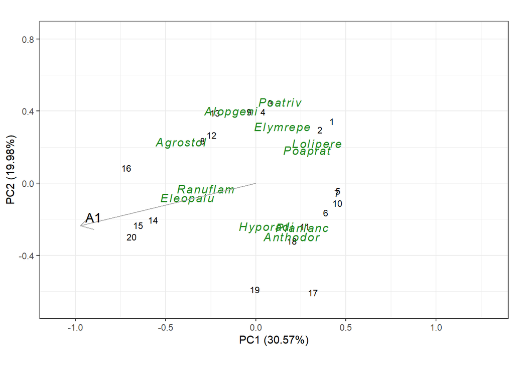

```r
pca.plot <- ggord(pca.dune, xlims=c(-1.2,1.4), ylims=c(-0.75,0.9),
                  axes=c(1,2),
                  size=3,
                  obslab=TRUE,
                  arrow=NULL,
                  txt=NULL,
                  addpts=sp.scores.skim,
                  addsize=4,
                  ptslab=TRUE,
                  addcol="forestgreen")
pca.plot +
  coord_fixed() + # ajout des vecteurs de envfit
  geom_segment(data = vect,
               aes(x = 0, xend = PC1, y = 0, yend = PC2),
               arrow = arrow(length = unit(0.5, "cm")), colour = "darkgrey") +
  geom_text_repel(data = vect, aes(x = PC1, y = PC2, label = variable.env, size = 3), show.legend = FALSE)
```

Maintenant, on va ajouter des ellipses autour des sites appartenant à des groupes similaires. On va aussi revenir à des symboles au lieu du nom des sites et changer la couleur du texte des espèces.

[output not shown]

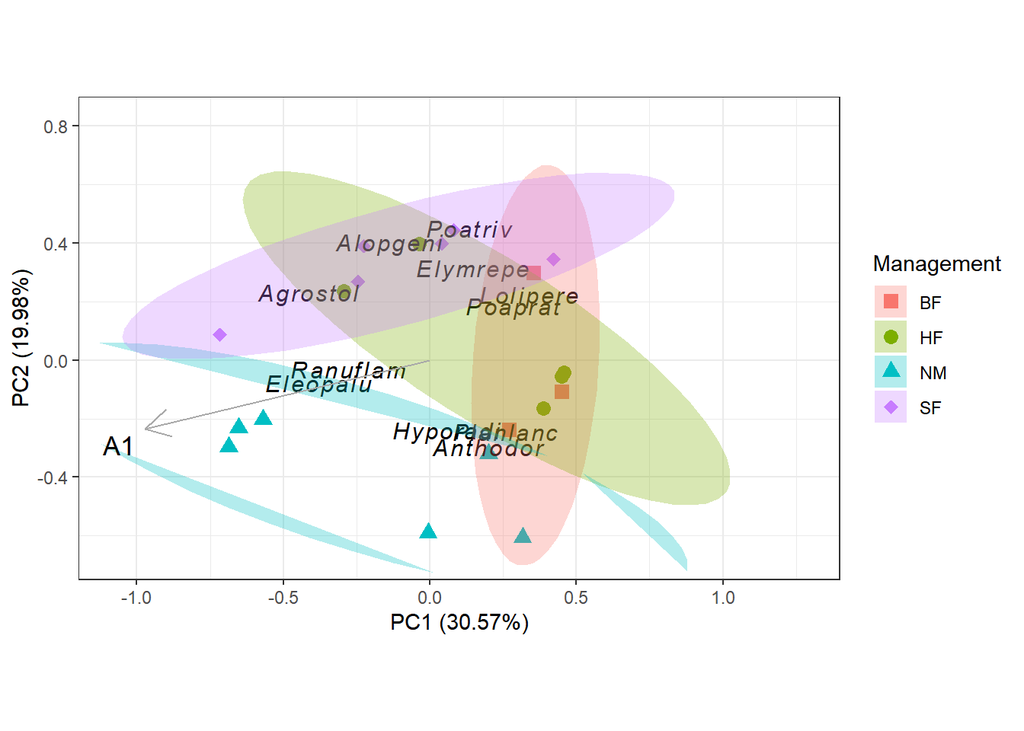

```r
pca.plot <- ggord(pca.dune, xlims=c(-1.2,1.4), ylims=c(-0.75,0.9),
                  axes=c(1,2),
                  grp_in=dune.env$Management, # ajout des ellipses en fonction du type de Management
                  grp_title = "Management",
                  ellipse_pro=0.95, # valeur de confiance pour les ellipses
                  alpha_el=0.3, # transparence des ellipses
                  size=3,
                  obslab=FALSE, # changement de texte à points pour sites
                  arrow=NULL,
                  txt=NULL,
                  addpts=sp.scores.skim,
                  addsize=4,
                  ptslab=TRUE,
                  addcol="black", # couleur des espèces
                  alpha = 1)
pca.plot +
    scale_shape_manual('Groups', values = c(15,16,17,18)) + # Symboles pour les sites en fonction de leur groupe. Assurer vous d'avoir un nombre de symboles correspondant au nombre de groupes.
    coord_fixed() +
    geom_segment(data = vect,
               aes(x = 0, xend = PC1, y = 0, yend = PC2),
               arrow = arrow(length = unit(0.5, "cm")), colour = "darkgrey") +
    geom_text_repel(data = vect, aes(x = PC1, y = PC2, label = variable.env, size = 3), show.legend = FALSE)
```

Voici une légende indiquant quels symboles sont associées aux différentes valeurs numériques de la couche `scale_shape_manual`.

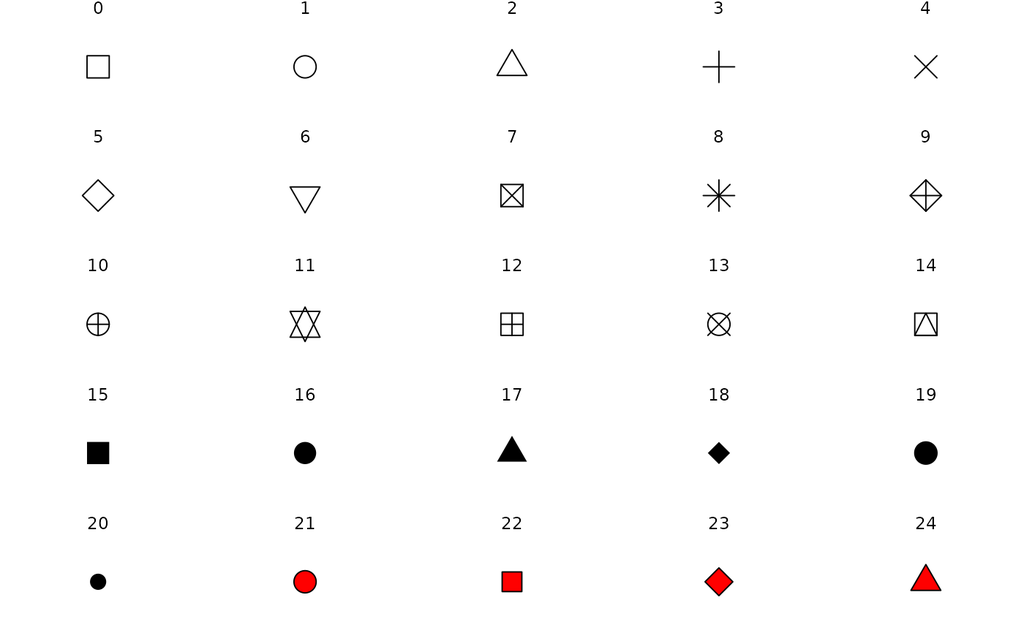

Changer les couleurs des groupes On va extraire les codes des couleurs d’une palette de RColorBrewer avec la fonction `brewer.pal`

```r
library(RColorBrewer)
pca.colors <- brewer.pal(n = 4, name = "Dark2") # Hexadecimal color specification
```

On va incorporer ces codes de couleurs dans un argument. On déplace la légende vers le haut.

```r
pca.plot <- ggord(pca.dune, xlims=c(-1.2,1.4), ylims=c(-0.75,0.9),
                  axes=c(1,2),
                  grp_in=dune.env$Management,
                  grp_title = "Management",
                  cols=pca.colors, # ajout des couleurs choisies
                  ellipse_pro=0.95,
                  alpha_el=0.3,
                  size=3,
                  obslab=FALSE,
                  arrow=NULL,
                  txt=NULL,
                  addpts=sp.scores.skim,
                  addsize=4,
                  ptslab=TRUE,
                  addcol="black",
                  alpha = 1)
pca.plot <- pca.plot + # ici j'enregistre l'ensemble des arguments précédents et suivants dans mon objet pca.plot.
    scale_shape_manual('Groups', values = c(15,16,17,18)) +
    coord_fixed() +
    geom_segment(data = vect,
               aes(x = 0, xend = PC1, y = 0, yend = PC2),
               arrow = arrow(length = unit(0.5, "cm")), colour = "darkgrey") +
    geom_text_repel(data = vect, aes(x = PC1, y = PC2, label = variable.env, size = 3), show.legend = FALSE)+
    theme(legend.position = 'top') # mettre la légende en haut
```

[output not shown]

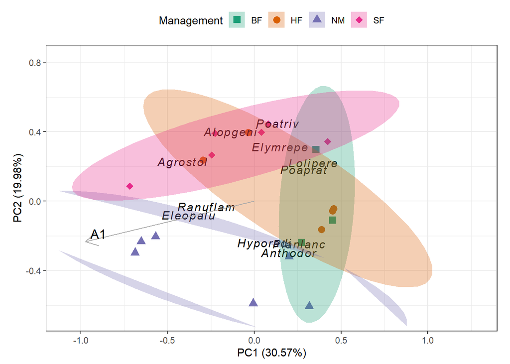

```r
pca.plot
```

Créer un thème custom pour ggplot.

```r
super_theme <- theme(
        panel.background = element_blank(),
        #panel.border = element_blank(),
        panel.grid = element_blank(),
        axis.line = element_line("gray25"),
        text = element_text(size = 12),
        axis.text = element_text(size = 10, colour = "gray25"),
        axis.title = element_text(size = 14, colour = "gray25"),
        legend.title = element_text(size = 14),
        legend.text = element_text(size = 14),
        legend.key = element_blank())
```

Ajouter ce thème au graphique.

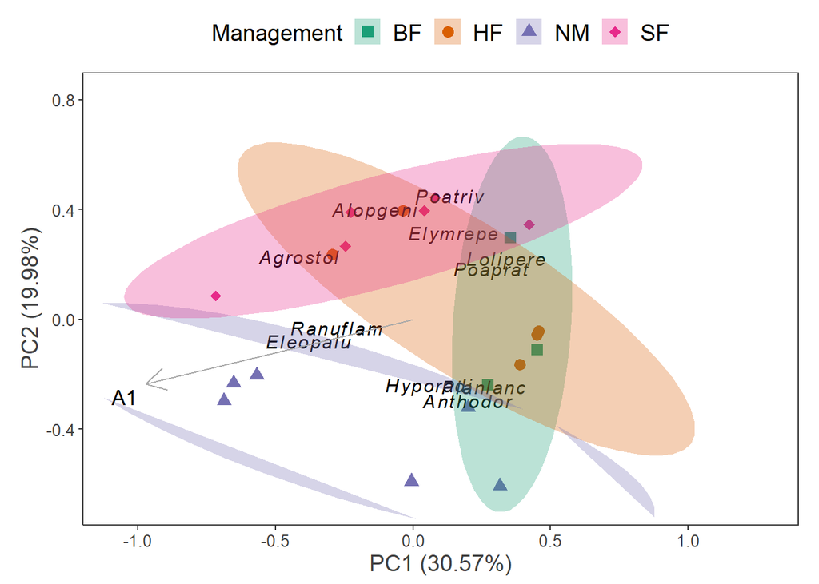

```r
pca.plot + super_theme
```

On va rajouter du texte!

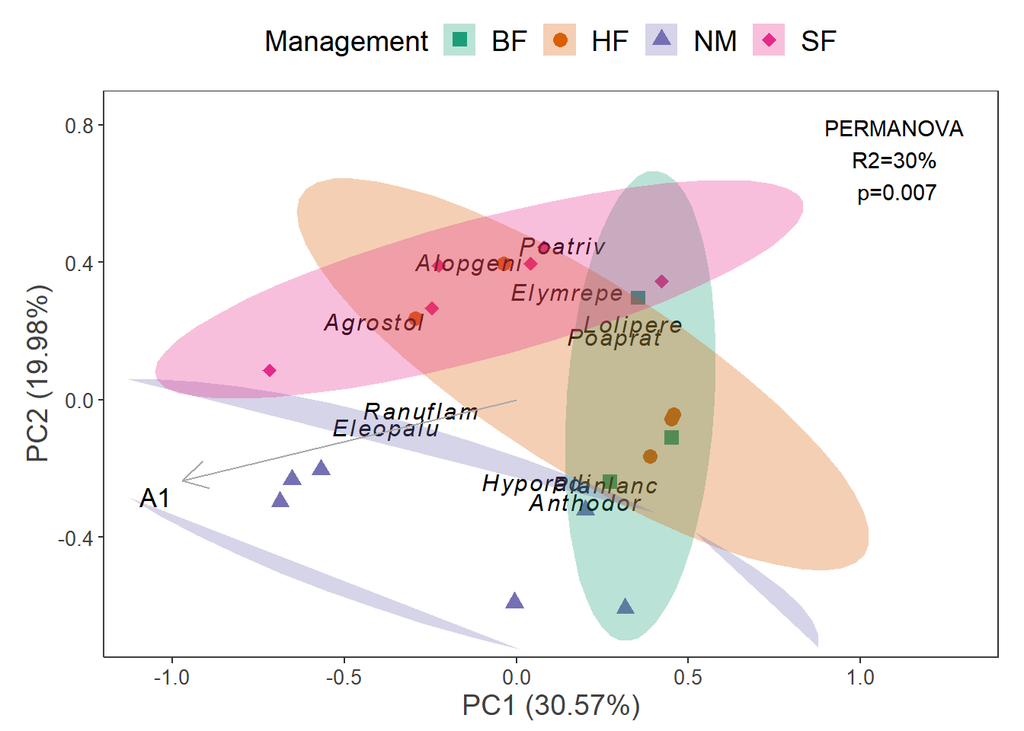

```r
pca.plot + annotate("text", x = 1.1, y = 0.7, label = "PERMANOVA\nR2=30%\n p=0.007") +
    super_theme
```

Satisfait? On sauvegarde l’image en png. Par défaut, ggplot enregistre le dernier graphique créé. Ici on copie-colle le code du graphique ci haut, puis sauvegarde ce graphique avec la fonction `ggsave` dans un dossier qu’on a créé (figures/).

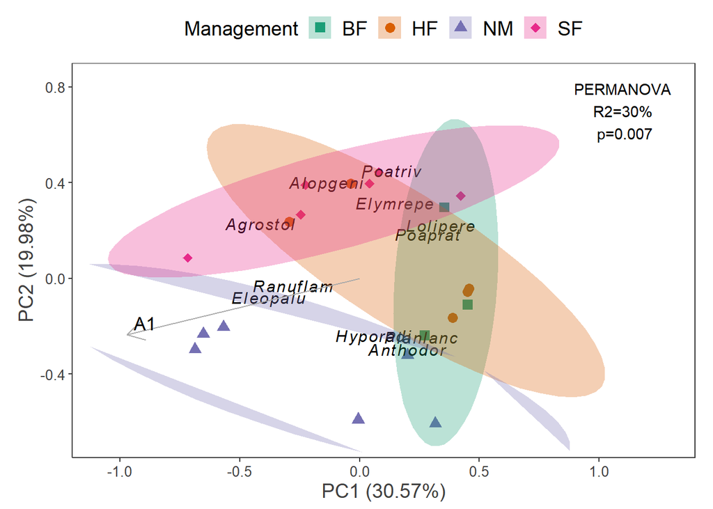

```r
pca.plot + annotate("text", x = 1.1, y = 0.7, label = "PERMANOVA\nR2=30%\n p=0.007") +
    super_theme
```

```r
ggsave("pca.png", path="./figures/")
```

Cet atelier n’est pas fait pour vous montrer à utiliser une esthétique particulière, mais bien pour vous familiariser avec les options (infinies…) permettant de personnaliser un graphique d’ordination. Vous allez voir des figures d’ordination dans la littérature. Essayez de reproduire l’esthétique qui vous semble la plus appropriée… ou, tout simplement, amusez-vous les artistes!!

# CA

## Préparation des données

Faire une CA avec la fonction `cca`.

```r
ca.dune <- cca(dune)
ca.summary <- summary(ca.dune)
summary(ca.dune)
```

```
##
## Call:
## cca(X = dune)
##
## Partitioning of scaled Chi-square:
##               Inertia Proportion
## Total           2.115          1
## Unconstrained   2.115          1
##
## Eigenvalues, and their contribution to the scaled Chi-square
##
## Importance of components:
##                          CA1    CA2    CA3     CA4     CA5     CA6     CA7
## Eigenvalue            0.5360 0.4001 0.2598 0.17598 0.14476 0.10791 0.09247
## Proportion Explained  0.2534 0.1892 0.1228 0.08319 0.06844 0.05102 0.04372
## Cumulative Proportion 0.2534 0.4426 0.5654 0.64858 0.71702 0.76804 0.81175
##                           CA8     CA9    CA10    CA11    CA12    CA13     CA14
## Eigenvalue            0.08091 0.07332 0.05630 0.04826 0.04125 0.03523 0.020529
## Proportion Explained  0.03825 0.03466 0.02661 0.02282 0.01950 0.01665 0.009705
## Cumulative Proportion 0.85000 0.88467 0.91128 0.93410 0.95360 0.97025 0.979955
##                           CA15     CA16     CA17     CA18     CA19
## Eigenvalue            0.014911 0.009074 0.007938 0.007002 0.003477
## Proportion Explained  0.007049 0.004290 0.003753 0.003310 0.001644
## Cumulative Proportion 0.987004 0.991293 0.995046 0.998356 1.000000
##
## Scaling 2 for species and site scores
## * Species are scaled proportional to eigenvalues
## * Sites are unscaled: weighted dispersion equal on all dimensions
##
##
## Species scores
##
##               CA1      CA2      CA3       CA4       CA5      CA6
## Achimill  0.90859 -0.08461  0.58636 -0.008919 -0.660183 -0.18877
## Agrostol -0.93378  0.20651 -0.28165  0.024293 -0.139326 -0.02256
## Airaprae  1.00434 -3.06749 -1.33773  0.194305 -1.081813 -0.53699
## Alopgeni -0.40088  0.61839 -0.85013  0.346740  0.016509  0.10169
## Anthodor  0.96676 -1.08361  0.17188  0.459788 -0.607533 -0.30425
## Bellpere  0.50018  0.35503  0.15239 -0.704153 -0.058546  0.07308
## Bromhord  0.65762  0.40634  0.30685 -0.496751 -0.561358  0.07004
```

[output cut: 33 more lines]

```
## 6   0.85633  0.0005408  1.39735  1.59909  0.65494 -0.19386
## 7   0.87149  0.2547040  0.86830  0.90468  0.17385 -0.03446
## 8  -0.76268  0.2968459 -0.35648 -0.10772  0.17507 -0.36444
## 9  -0.09693  0.7864314 -0.86492  0.40090  0.28704 -1.02783
## 10  0.87885  0.0353136  0.82987 -0.68053 -0.75438  0.81070
## 11  0.64223 -0.4440332  0.17371 -1.09684  1.37462  2.00626
## 12 -0.28557  0.6656161 -1.64423  1.71496  0.65381  1.17376
## 13 -0.42445  0.8440195 -1.59029  1.24876 -0.20748  0.87566
## 14 -1.91996 -0.5351062  1.39863 -0.08575 -2.21317  2.43044
## 15 -1.91384 -0.5079036  0.96567  0.04227 -0.50681  0.19370
## 16 -2.00229 -0.1090627  0.33414  0.33760 -0.50097 -0.76159
## 17  1.47545 -2.7724102 -0.40859  0.75117 -2.59425 -1.10122
## 18  0.31241 -0.6328355  0.66501 -1.12728  2.65575  0.97565
## 19  0.69027 -3.2642026 -1.95716 -0.17694 -0.07352 -0.16083
## 20 -1.94438 -1.0688809  0.66595 -0.55317  1.59606 -1.70292
```

Extraction de la proportion de la variance expliquée par les deux premiers axes (pour s’y référer plus rapidement).

```r
prop.expl.ca1 <- ca.summary$cont$importance[2, "CA1"]
prop.expl.ca2 <- ca.summary$cont$importance[2, "CA2"]
```

envfit

```r
(ca.envfit <- envfit(ca.dune, dune.env))
```

```
##
## ***VECTORS
##
##          CA1       CA2     r2 Pr(>r)
## A1 -0.998160 -0.060614 0.3104  0.043 *
## ---
## Signif. codes:  0 '***' 0.001 '**' 0.01 '*' 0.05 '.' 0.1 ' ' 1
## Permutation: free
## Number of permutations: 999
##
## ***FACTORS:
##
## Centroids:
##                  CA1     CA2
## Moisture1     0.7484  0.1423
## Moisture2     0.4652  0.2156
## Moisture4    -0.1827  0.7315
## Moisture5    -1.1143 -0.5708
## ManagementBF  0.7258  0.1413
## ManagementHF  0.3867  0.2960
## ManagementNM -0.6517 -1.4405
## ManagementSF -0.3376  0.6761
## UseHayfield   0.2861 -0.6488
## UseHaypastu   0.0735  0.5602
## UsePasture   -0.5163 -0.0508
## Manure0      -0.6517 -1.4405
## Manure1       0.4639  0.1738
## Manure2       0.5872  0.3600
## Manure3      -0.5187  0.3172
## Manure4       0.2059  0.8775
##
## Goodness of fit:
##                r2 Pr(>r)
## Moisture   0.4113  0.006 **
## Management 0.4441  0.003 **
## Use        0.1845  0.078 .
## Manure     0.4552  0.006 **
## ---
## Signif. codes:  0 '***' 0.001 '**' 0.01 '*' 0.05 '.' 0.1 ' ' 1
## Permutation: free
## Number of permutations: 999
```

Pour incorporer les vecteurs résultant de ce test, il faut d’abord les extraire et les mettre dans un dataframe.

```r
vect.ca.env <- data.frame(ca.envfit[["vectors"]][["arrows"]])
vect.ca.env$variable.env<-rownames(vect.ca.env)
```

```r
dune.dist.chi2 <- vegdist(dune, method='chisq')
disper.dune.chi2 <- betadisper(dune.dist.chi2, dune.env$Management)
anova(disper.dune.chi2)
```

```
## Analysis of Variance Table
##
## Response: Distances
##           Df Sum Sq Mean Sq F value   Pr(>F)
## Groups     3 3.0277  1.0092  5.9124 0.006493 **
## Residuals 16 2.7311  0.1707
## ---
## Signif. codes:  0 '***' 0.001 '**' 0.01 '*' 0.05 '.' 0.1 ' ' 1
```

```r
permanova.dune.ca <- adonis2(dune.dist.chi2 ~ Management, data = dune.env)
permanova.dune.ca
```

```
## Permutation test for adonis under reduced model
## Terms added sequentially (first to last)
## Permutation: free
## Number of permutations: 999
##
## adonis2(formula = dune.dist.chi2 ~ Management, data = dune.env)
##            Df SumOfSqs      R2      F Pr(>F)
## Management  3   12.399 0.25508 1.8263  0.012 *
## Residual   16   36.208 0.74492
## Total      19   48.606 1.00000
## ---
## Signif. codes:  0 '***' 0.001 '**' 0.01 '*' 0.05 '.' 0.1 ' ' 1
```

Ici, le résultat du test de dispersion indique que la différence dans la composition végétale entre les types d’aménagement qui est “perçue” par la PERMANOVA pourrait être du à la différence dans la variance interne en composition des groupes.

Extraire les scores de CA avec la fonction `scores`

```r
site.scores.dune.ca <- scores(ca.dune, display="sites", choices=c(1,2)) # ici on garde que les scores des axes 1 et 2 mais on aurait pu extraire tous les scores aussi.
site.scores.dune.ca <- data.frame(site.scores.dune.ca)
Management <- dune.env$Management
site.scores.ca <- cbind(site.scores.dune.ca, Management)
sp.scores.dune.ca <- scores(ca.dune, display="species", choices=c(1,2)) # idem scores axes 1 et 2 seulement
sp.scores.dune.ca <- data.frame(sp.scores.dune.ca)
```

Comme on a fait acvec les scores des espèces de la PCA, on ne garde que les plus hautes valeurs absolues.

```r
A.ca <- top_n(sp.scores.dune.ca, 3, CA1)
B.ca <- top_n(sp.scores.dune.ca, -3, CA1)
C.ca <- top_n(sp.scores.dune.ca, 3, CA2)
D.ca <- top_n(sp.scores.dune.ca, -3, CA2)
sp.scores.skim.ca <- bind_rows(A.ca,B.ca,C.ca,D.ca)
sp.scores.skim.ca <- distinct(sp.scores.skim.ca)
```

Graphique simple avec les fonctions `plot` et `ordiplot`.

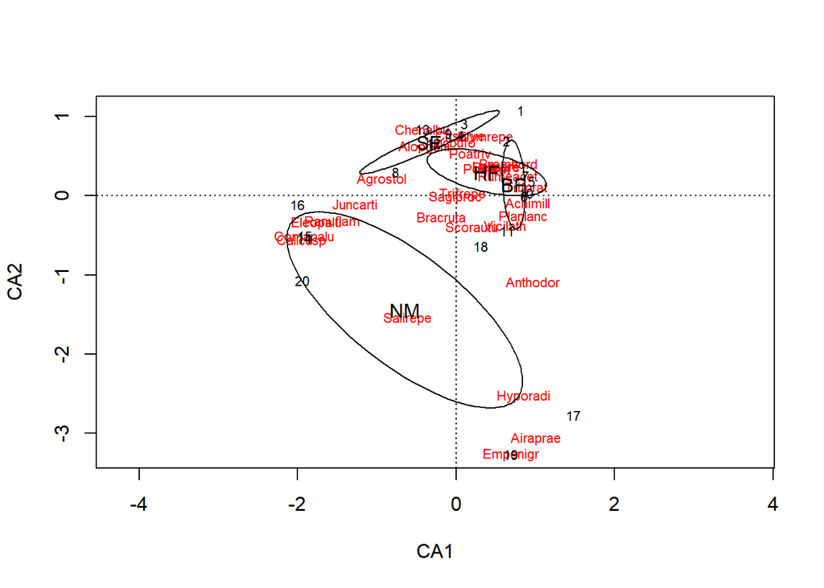

```r
plot(ca.dune)
ordiellipse(ca.dune, dune.env$Management, display = "sites", kind = "sd", label = T)
```

## ggplot

On commence le graphique ggplot. On peut faire un graphique qui ressemble à celui fait par `plot` en ajoutant “à la main” les sites et les espèces (en fonction de leurs scores extraits).

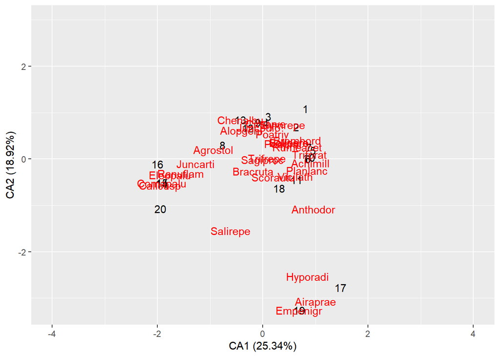

```r
ca.plot <-
  ggplot(data = site.scores.ca, aes(x = CA1, y = CA2)) +
  expand_limits(x=c(-4,4), y=c(-1,3)) + # sert à modifier l'échelle numérique du graphique
  geom_text(data = site.scores.dune.ca, aes(x = CA1, y = CA2, label= rownames(site.scores.dune.ca)), color = "black") + # ajout du texte des sites
  geom_text(data = sp.scores.dune.ca, aes(x = CA1, y = CA2, label= rownames(sp.scores.dune.ca)), color = "red") + # ajout du texte des espèces
  xlab("CA1 (25.34%)") + ylab("CA2 (18.92%)") # contrairement avec la fonction ggord, on écrit la variation expliqué par les axes soi même
ca.plot
```

On peut rajouter les vecteurs de note envfit.

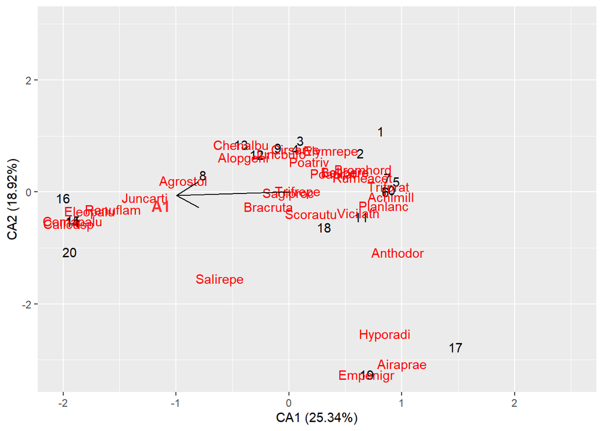

```r
ca.plot <-
  ggplot(data = site.scores.ca, aes(x = CA1, y = CA2)) +
  expand_limits(x=c(-2,2.5), y=c(-1,3)) + # on zoom in sur l'échelle
  geom_text(data = site.scores.dune.ca, aes(x = CA1, y = CA2, label= rownames(site.scores.dune.ca)), color = "black") +
  geom_text(data = sp.scores.dune.ca, aes(x = CA1, y = CA2, label= rownames(sp.scores.dune.ca)), color = "red") +
  xlab("CA1 (25.34%)") + ylab("CA2 (18.92%)") +
  geom_segment(data = vect.ca.env, # ajout des vecteurs envfit
               aes(x = 0, xend = CA1, y = 0, yend = CA2),
               arrow = arrow(length = unit(0.75, "cm")), color = "black") +
  geom_text_repel(data = vect.ca.env, aes(x = CA1, y = CA2, label = variable.env, size = 3), color = "firebrick1", fontface = "bold", show.legend = FALSE)
ca.plot
```

On va mettre des points pour les sites et changer leurs couleurs et leurs symboles en fonction de leur type d’aménagement. On va aussi mettre en graphique uniquement les espèces aux plus grands scores.

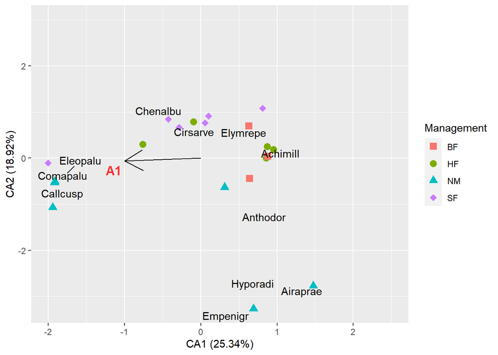

```r
ca.plot <-
  ggplot(data = site.scores.ca, aes(x = CA1, y = CA2), color = Management) + # on ajoute ici arg "color"
  expand_limits(x=c(-2,2.5), y=c(-1,3)) +
  geom_point(aes(shape = Management, color = Management), size=3) + # on change de geom_text à geom_point pour les sites
  xlab("CA1 (25.34%)") + ylab("CA2 (18.92%)") +
  geom_text_repel(data = sp.scores.skim.ca, aes(x = CA1, y = CA2), label=rownames(sp.scores.skim.ca), color = "black") + # on garde geom_text pour les espèces mais on change de dataframe
  geom_segment(data = vect.ca.env, # ajout des vecteurs envfit
               aes(x = 0, xend = CA1, y = 0, yend = CA2),
               arrow = arrow(length = unit(0.75, "cm")), color = "black") +
  geom_text_repel(data = vect.ca.env, aes(x = CA1, y = CA2, label = variable.env, size = 3), color = "firebrick1", fontface = "bold", show.legend = FALSE) +
  scale_shape_manual(values = c(15,16,17,18)) # on décide des symboles à utiliser (se référer à la charte plus haut)
ca.plot
```

On va ajouter des ellipses autour de nos sites en fonction de leur type d’aménagement. On va d’abord utiliser la fonction `ggordiplot` de la librairie ggordiplots pour extraire les données des ellipses. (on peut aussi extraire les données de hulls et spiders.) En même temps, ça nous donne un autre beau graphique, mais qui est plus complexe à modifier.

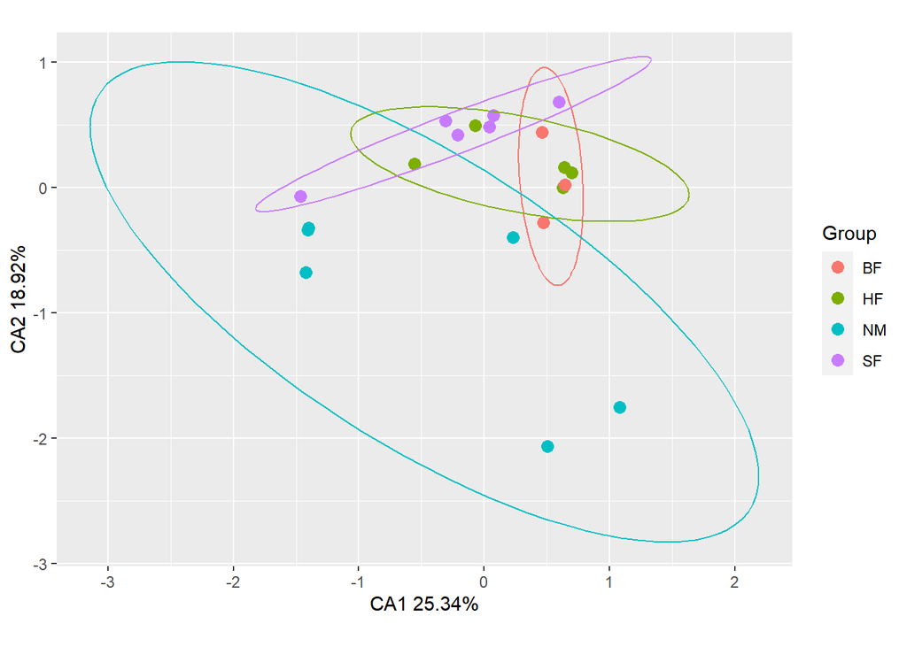

```r
library(ggordiplots)
ca.ggordiplot <- gg_ordiplot(ca.dune, groups = dune.env$Management, kind = "sd", conf = 0.95, pt.size = 3) # on spécifie l'intervalle de confiance des ellipses
```

```r
names(ca.ggordiplot)
```

```
## [1] "df_ord"      "df_mean.ord" "df_ellipse"  "df_hull"     "df_spiders"
## [6] "plot"
```

```r
ca.ellipses <- ca.ggordiplot$df_ellipse # extraction des valeurs des ellipses
```

On prend les valeurs des ellipses qu’on vient d’extraire pour mettre en graphique dans ggplot ces ellipses. Om change aussi les couleurs de nos groupes.

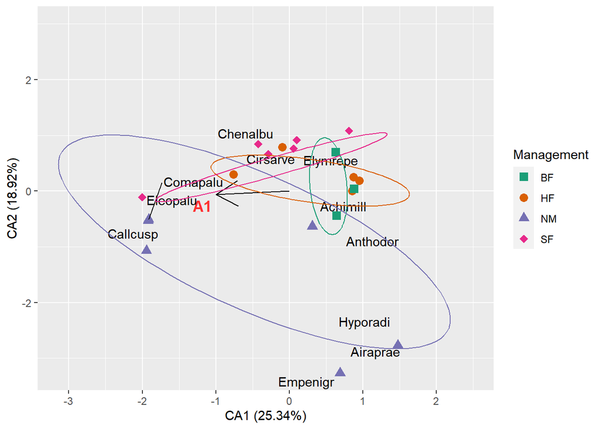

```r
ca.plot <-
  ggplot(data = site.scores.ca, aes(x = CA1, y = CA2), color = Management) +
  expand_limits(x=c(-2,2.5), y=c(-1,3)) +
  geom_point(aes(shape = Management, color = Management), size=3) +
  xlab("CA1 (25.34%)") + ylab("CA2 (18.92%)") +
  geom_text_repel(data = sp.scores.skim.ca, aes(x = CA1, y = CA2), label=rownames(sp.scores.skim.ca), color = "black") +
  geom_segment(data = vect.ca.env, # ajout des vecteurs envfit
               aes(x = 0, xend = CA1, y = 0, yend = CA2),
               arrow = arrow(length = unit(0.75, "cm")), color = "black") +
  geom_text_repel(data = vect.ca.env, aes(x = CA1, y = CA2, label = variable.env, size = 3), color = "firebrick1", fontface = "bold", show.legend = FALSE) +
  scale_shape_manual(values = c(15,16,17,18)) +
  geom_path(data = ca.ellipses, aes(x = x, y = y, color = Group), show.legend = FALSE) + # ajout des ellipses
  scale_color_brewer(palette="Dark2") # changement des couleurs des ellipses et des sites
ca.plot
```

Enfin, on pourrait rajouter notre thème personnalisé, mais optons pour un existant comme “bw”.

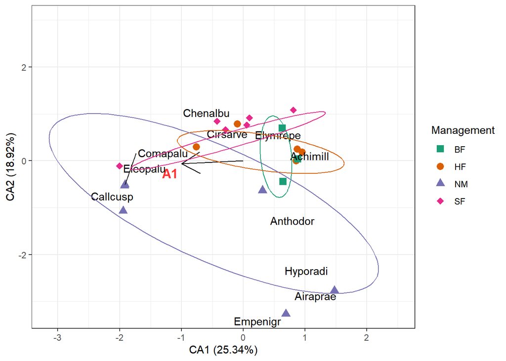

```r
ca.plot + theme_bw()
```

Comme mentionnée précédemment, vous pouvez modifier presque à l’infini votre graphique!

On sauvegarde notre figure de CA.

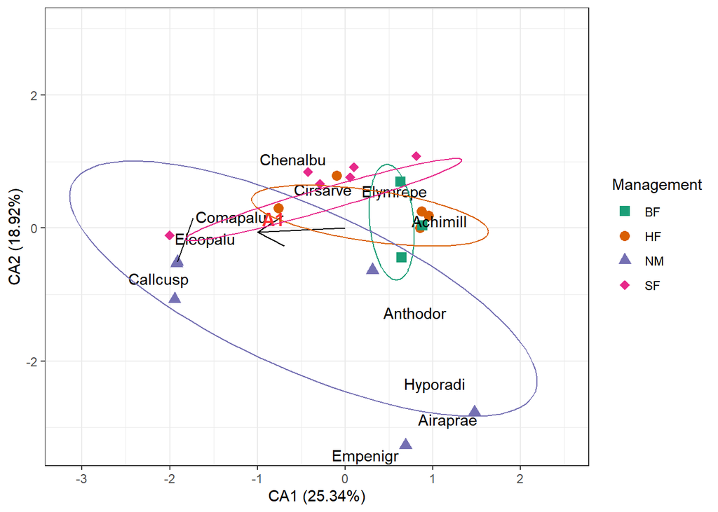

```r
ca.plot + theme_bw()
```

```r
ggsave("ca.png", path="./figures/")
```

# PCoA

## Préparation des données

```r
dune.bray <- vegdist(dune, method='bray')
```

## Faire une PCoA dans R

```r
pcoa.dune <- cmdscale(dune.bray, k =(nrow(dune) - 1), eig = TRUE)
summary(pcoa.dune)
```

```
##        Length Class  Mode
## points 280    -none- numeric
## eig     20    -none- numeric
## x        0    -none- NULL
## ac       1    -none- numeric
## GOF      2    -none- numeric
```

Extraire les scores de la PCoA.

```r
site.scores.pcoa <- scores(pcoa.dune) # site scores
sp.scores.pcoa <- wascores(pcoa.dune$points, dune) # species scores
site.scores.pcoa <- data.frame(site.scores.pcoa)
sp.scores.pcoa <- data.frame(sp.scores.pcoa)
Management <- dune.env$Management
site.scores.pcoa <- cbind(site.scores.pcoa, Management)
```

Comme on a fait acec les scores des espèces de la PCA et de la CA, on ne garde que les plus hautes valeurs absolues, mais cette fois ci, des axes 1 et 3 (pour le plaisir)!.

```r
A.pcoa <- top_n(sp.scores.pcoa, 3, X1)
B.pcoa <- top_n(sp.scores.pcoa, -3, X1)
C.pcoa<- top_n(sp.scores.pcoa, 3, X3)
D.pcoa <- top_n(sp.scores.pcoa, -3, X3)
sp.scores.skim.pcoa <- bind_rows(A.pcoa,B.pcoa,C.pcoa,D.pcoa)
sp.scores.skim.pcoa <- distinct(sp.scores.skim.pcoa)
```

envfit SUR LES AXES 1 ET 3 (on n’oublie pas!)

```r
(pcoa.envfit <- envfit(pcoa.dune, dune.env, choices=c(1,3)))
```

```
##
## ***VECTORS
##
##         Dim1      Dim3    r2 Pr(>r)
## A1 0.9999700 0.0078085 0.379  0.023 *
## ---
## Signif. codes:  0 '***' 0.001 '**' 0.01 '*' 0.05 '.' 0.1 ' ' 1
## Permutation: free
## Number of permutations: 999
##
## ***FACTORS:
##
## Centroids:
##                 Dim1    Dim3
## Moisture1    -0.2650  0.0607
## Moisture2    -0.1620  0.0000
## Moisture4     0.1065 -0.2369
## Moisture5     0.3271  0.0069
## ManagementBF -0.2694  0.0706
## ManagementHF -0.1350 -0.0394
## ManagementNM  0.1822  0.0370
## ManagementSF  0.0650 -0.0395
## UseHayfield  -0.0608 -0.0240
## UseHaypastu  -0.0227 -0.0210
## UsePasture    0.1213  0.0673
## Manure0       0.1822  0.0370
## Manure1      -0.1654  0.0175
## Manure2      -0.1648 -0.0944
## Manure3       0.1397 -0.0451
## Manure4      -0.1656  0.0944
##
## Goodness of fit:
##                r2 Pr(>r)
## Moisture   0.6918  0.001 ***
## Management 0.2634  0.110
## Use        0.0614  0.640
## Manure     0.2892  0.217
## ---
## Signif. codes:  0 '***' 0.001 '**' 0.01 '*' 0.05 '.' 0.1 ' ' 1
## Permutation: free
## Number of permutations: 999
```

Pour incorporer les vecteurs résultant de ce test, il faut d’abord les extraire et les mettre dans un dataframe.

```r
vect.pcoa.env <- data.frame(pcoa.envfit[["vectors"]][["arrows"]])
vect.pcoa.env$variable.env <- rownames(vect.pcoa.env)
```

```r
dune.dist.bray <- vegdist(dune, method='bray')
disper.dune.bray <- betadisper(dune.dist.bray, dune.env$Management)
anova(disper.dune.bray)
```

```
## Analysis of Variance Table
##
## Response: Distances
##           Df  Sum Sq  Mean Sq F value Pr(>F)
## Groups     3 0.13831 0.046104  1.9506 0.1622
## Residuals 16 0.37816 0.023635
```

```r
permanova.dune.pcoa <- adonis2(dune.dist.bray ~ Management, data = dune.env)
permanova.dune.pcoa
```

```
## Permutation test for adonis under reduced model
## Terms added sequentially (first to last)
## Permutation: free
## Number of permutations: 999
##
## adonis2(formula = dune.dist.bray ~ Management, data = dune.env)
##            Df SumOfSqs      R2      F Pr(>F)
## Management  3   1.4686 0.34161 2.7672  0.003 **
## Residual   16   2.8304 0.65839
## Total      19   4.2990 1.00000
## ---
## Signif. codes:  0 '***' 0.001 '**' 0.01 '*' 0.05 '.' 0.1 ' ' 1
```

Extraction des ellipses de la PCoA (axes 1 et 3!)

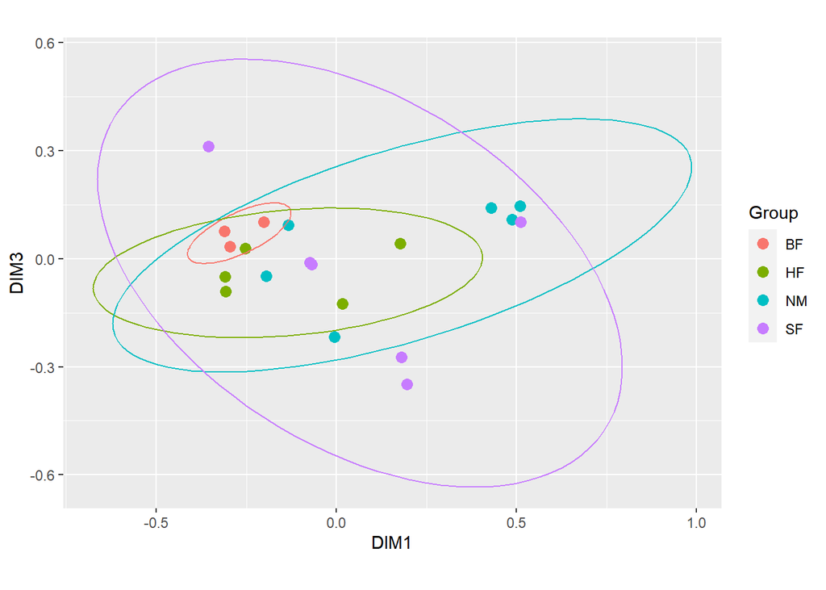

```r
library(ggordiplots)
pcoa.ggordiplot <- gg_ordiplot(pcoa.dune, choices = c(1,3), groups = dune.env$Management, kind = "sd", conf = 0.95, pt.size = 3)
```

```r
names(pcoa.ggordiplot)
```

```
## [1] "df_ord"      "df_mean.ord" "df_ellipse"  "df_hull"     "df_spiders"
## [6] "plot"
```

```r
pcoa.ellipses <- pcoa.ggordiplot$df_ellipse
```

## ggplot

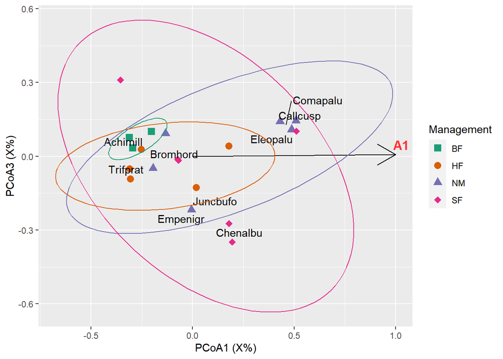

```r
pcoa.plot <-
  ggplot(data = site.scores.pcoa, aes(x = Dim1, y = Dim3), color = Management) +
  expand_limits(x=c(-0.35,0.6), y=c(-0.35,0.35)) +
  geom_point(aes(shape = Management, color = Management), size=3) +
  xlab("PCoA1 (X%)") + ylab("PCoA3 (X%)") +
  geom_text_repel(data = sp.scores.skim.pcoa, aes(x = X1, y = X3), label=rownames(sp.scores.skim.pcoa), color = "black") +
  geom_segment(data = vect.pcoa.env,
               aes(x = 0, xend = Dim1, y = 0, yend = Dim3),
               arrow = arrow(length = unit(0.75, "cm")), color = "black") +
  geom_text_repel(data = vect.pcoa.env, aes(x = Dim1, y = Dim3, label = variable.env, size = 3), color = "firebrick1", fontface = "bold", show.legend = FALSE) +
  scale_shape_manual(values = c(15,16,17,18)) +
  geom_path(data = pcoa.ellipses, aes(x = x, y = y, color = Group), show.legend = FALSE) +
  scale_color_brewer(palette="Dark2")
pcoa.plot
```

```r
ggsave("pcoa.png", path="./figures/")
```

- FIN -